# The Fourier Transform (Part 1)

## Agenda

- Fourier Transform as the Limit of a Fourier Series
- Doing the Maths
- Special forms of the Fourier Transform
- Properties of the Fourier Transform
- Computing Fourier Transforms in Matlab

## Scope and Background Reading

This session continues our coverage of **Fourier Analysis** with an introduction to the **Fourier Transform**.

- **Fourier Series** is used when we are dealing with signals that are *periodic* in time. It is based on harmonics of the fundamental frequency $\omega_0$ of the periodic signal where the period $T = 2\pi/\omega_0$.
- The line spectrum occur at integer multiples of the fundamental frequency $k\omega_0$ and is a *discrete* (or sampled) function of frequency.
- As the period $T$ is increased, the distance between harmonics decreases because $\omega_0$ reduces.
- In the limit $T\to \infty$, the signal becomes **aperiodic** and $k\omega_0 \to \omega$ which is a *continuous* function of frequency.

This is the basis of the **Fourier Transform** which is very important as the basis for data transmission, signal filtering, and the determination of system frequency reponse.

The material in this presentation and notes is based on Chapter 8 (Starting at Section 8.1) of [Steven T. Karris, Signals and Systems: with Matlab Computation and Simulink Modelling, 5th Edition.](https://ebookcentral.proquest.com/lib/swansea-ebooks/reader.action?ppg=271&docID=3384197&tm=1518709033960) from the **Required Reading List**. I also used Chapter 5 of [Benoit Boulet, Fundamentals of Signals and Systems](https://ebookcentral.proquest.com/lib/swansea-ebooks/reader.action?ppg=194&docID=3135971&tm=1518709078944) from the **Recommended Reading List**.

## Fourier Transform as the Limit of a Fourier Series

We start by considering the pulse train that we used in the last lecture and demonstrate that the discrete line spectra for the Fourier Series becomes a continuous spectrum as the signal becomes aperiodic.

Let $\tilde x(t)$ be the Fourier series of the rectangular pulse train shown below:

[figure not shown]

## Fourier Series

In the [previous lecture](http://nbviewer.jupyter.org/github/cpjobling/EG-247-Resources/blob/master/week5/exp_fs2.ipynb) we used*

$$C_k = \frac{1}{2\pi}\int_{-\pi/w}^{\pi/w} Ae^{-jk(\omega_0 t)}\,d(\omega_0 t) = \frac{A}{2\pi}\int_{-\pi/w}^{\pi/w} e^{-jk(\omega_0 t)}\,d(\omega_0 t) $$

to compute the line spectra.

### From the Time Point of View

If we instead take a time point-of-view and let $A = 1$

$$C_k = \frac{1}{T}\int_{-t_0}^{t_0} e^{-jk\omega_0 t}\,dt.$$

Let's complete the analysis on the whiteboard.

### The Sinc Function

The function, $\sin(x)/x$ crops up again and again in Fourier analysis. The Fourier coefficients $C_k$ are scaled *samples* of the real continuous *normalized sinc* function defined as follows:

$$\operatorname{sinc} u: = \frac{{\sin \pi u}}{{\pi u}},\;u \in \mathbb{R}.$$

The function is equal to 1 at $u=0$* and has zero crossings at $u=\pm n,\; n=1,2,3,\ldots$ as shown below.

### Plot the sinc function

Plots:

$$sinc(u) = \frac{\sin \pi u}{\pi u},\; u \in \mathbb{R}$$

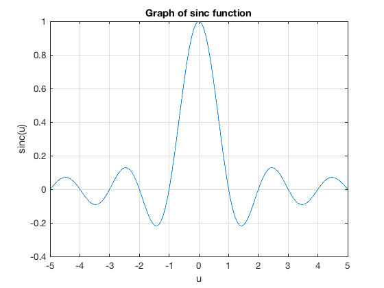

```matlab
x = linspace(-5,5,1000);
plot(x,sin(pi.*x)./(pi.*x))
grid
title('Graph of sinc function')
ylabel('sinc(u)')
xlabel('u')
```

### Duty cycle

- We define the duty cycle $\eta = 2t_0/T$ of the rectangular pulse train as the fraction of the time the signal is "on" (equal to 1) over one period.
- The duty cycle is often given as a percentage.

The spectral coefficients expressed using the normalized sinc function and the duty cycle can be written as

$$C_k = \frac{2t_0}{T}\frac{\sin\left(\frac{\pi k2t_0}{T}\right)}{\frac{\pi k2t_0}{T}}=\frac{2t_0}{T}\operatorname{sinc}\left(\frac{k2t_0}{T}\right)$$

$$C_k = \eta \operatorname{sinc}\left(k\eta\right)$$

### Normalize the spectral coefficients

Let us normalize the spectral coefficients of $\tilde x(t)$ by mutiplying them by $T$, and assume $t_0$ is fixed so that the duty cycle $\eta = 2t_0/T$ will decrease as we increase $T$:

$$T C_k = T\eta \operatorname{sinc}\left(k\eta\right)=2t_0\operatorname{sinc}\left(k\frac{2t_0}{T}\right)$$

Then the normalized coefficents $T C_k$ of the rectangular wave a sinc envelope with constant amplitude at the origin equal to $2t_0$, and a zero crossing at fixed frequency $\pi/t_0$ rad/s, both independent of T.

Plots follow (use duty_cycle.m to reproduce).

### Durty cycle 50%

[figure not shown]

### Duty cycle 12.5%

[figure not shown]

### Intuition leading to the Fourier Transform

- An aperiodic signal that has been made periodic by "repeating" its graph every $T$ seconds will have a line spectrum that becomes more and more dense as the fundamental period is made longer and longer.
- The line spectrum has the same continuous envelope.
- As $T$ goes to infinity, the line spectrum will become a continuous function of $\omega$.
- The *envelope* is this function.

### Doing the Maths

Fourier series coefficients for the rectangular wave are computed using:

$$C_k = \frac{1}{T}\int_{-t_0}^{t_0} \tilde{x}(t) e^{-jk(\omega_0 t)}\,dt $$

where $\omega_0 = 2\pi/T$ as usual.

Now define a signal $x(t)$ as a signal equal to $\tilde{x}(t)$ over one period and zero elsewhere.

[figure not shown]

### A rectangular pulse

The aperiodic signal, a single rectangular pulse, can be thought of as being periodic with an infinite fundamental period (we will let $T\to +\infty$ later).

Since $\tilde{x}(t)=x(t)$ over $t \in [-T/2,T/2]$, the spectral coefficients $C_k$ of the periodic signal $\tilde{x}(t)$ can be written in terms of the aperiodic signal $x(t)$ as follows:

$$C_k = \frac{1}{T}\int_{-\infty}^{+\infty}x(t)e^{-jk\omega t} dt.$$

Let us define the envelope $X(j\omega)$ of $T C_k$ (we already know this to be the sinc function):

$$X(j\omega):= \int_{-\infty}^{+\infty}x(t)e^{-j\omega t} dt = \int_{-t_0}^{+t_0}e^{-j\omega t} dt = 2t_0\operatorname{sinc}\left(\frac{t_0}{\pi}\omega\right).$$

The coefficients $C_k$ are therefore samples of the continuous envelope $X(j\omega)$:

$$C_k = \frac{1}{T}X(jk\omega_0).$$

### Back to the periodic signal

$\tilde{x}(t)$ has the Fourier series representation

$$\tilde{x}(t) = \sum_{k=-\infty}^{\infty}\frac{1}{T}X(jk\omega_0)e^{jk\omega_0 t}.$$

or equivalently, since $\omega_0 = 2\pi/T$:

$$\tilde{x}(t) = \frac{1}{2\pi} \sum_{k=-\infty}^{\infty}X(jk\omega_0)e^{jk\omega_0 t}\omega_0.$$

### Now take the limits

At the limit, as $T\to \infty$, in

$$\tilde{x}(t) = \frac{1}{2\pi} \sum_{k=-\infty}^{\infty} X(jk\omega_0)e^{jk\omega_0 t}\omega_0.$$

We get

- $\omega_0 \to d\omega$ – the fundamental frequency becomes infinitesimally small.
- $k\omega_0 \to \omega$ – harmonic frequencies get so close together they become a continuum.
- The summation becomes an integral.
- $\tilde{x}(t) \to x(t)$ – the periodic signal tends to the aperiodic signal.

### Define the Inverse Fourier and Fourier Transform

Putting these elements together we have an expression for the aperiodic signal in terms of its Fourier transform:

**Inverse Fourier Transform**:

$$x(t) = \frac{1}{2\pi} \int_{-\infty}^{\infty} X(j\omega)e^{j\omega t}\,d\omega := \mathcal{F}^{-1} \left\{X(j\omega)\right\}$$

Similarly, given the expression we have already seen for an arbitrary $x(t)$:

**Fourier Transform**:

$$X(j\omega) = \int_{-\infty}^{\infty}x(t)e^{-j\omega t}\,dt := \mathcal{F}\left\{x(t)\right\}.$$

### Fourier Transform Pair

- The two equations on the previous slide are called the *Fourier transform pair*.

## Properties of the Fourier Transform

Again, we will provide any properties that you might need in the examination.

You will find a number of these in the accompanying notes.

## Examples

1. Amplitude Modulation
2. Impulse response
3. Energy computation

### Example 1: Amplitude Modulation

Compute the result of multiplying a signal $f(t)$ by a carrier waveform $\cos \omega_c t$.

*Hint* use Euler's identity and the frequency shift property

### Example 2: Impulse response

A system has impulse response $f(t) = e^{-t}u_0(t)$. Compute the frequency sprectrum of this system.

### Example 3: Energy computation

An aperiodic real signal $f(t)$ has Fourier transform $F(j\omega)$. Compute the energy contained the signal between 5kHz and 10kHz.

## Computing Fourier Transforms in Matlab

MATLAB has the built-in **fourier** and **ifourier** functions that can be used to compute the Fourier transform and its inverse. We will explore some of thes in the next lab.

For now, here's an example:

### Example

Use Matlab to confirm the Fourier transform pair:

$$e^{-\frac{1}{2}t^2}\Leftrightarrow \sqrt{2\pi}e^{-\frac{1}{2}\omega^2}$$

```matlab
syms t v omega x;
ft = exp(-t^2/2);
Fw = fourier(ft,omega)
```

```
Fw =

2^(1/2)*pi^(1/2)*exp(-omega^2/2)
```

```matlab
pretty(Fw)
```

```
                    /        2 \
                    |   omega  |
sqrt(2) sqrt(pi) exp| - ------ |
                    \      2   /
```

Check by computing the inverse using ifourier

```matlab
ft = ifourier(Fw)
```

```
ft =

exp(-x^2/2)
```

## End of First Hour

*Summary*

- Fourier Transform as the Limit of a Fourier Series
- Doing the Maths
- Special forms of the Fourier Transform
- Properties of the Fourier Transform
- Computing Fourier Transforms in Matlab

*Next Hour*

- [Fourier transform of commonly occuring signals](http://nbviewer.ipython.org/github/cpjobling/EG-247-Resources/blob/master/week6/ft2.ipynb)